# Final project

Katherine Liu

6/6/2019

```r
# load all required packages
library(newsanchor) # download newspaper articles
library(robotstxt)  # get robots.txt
library(httr)       # http requests
library(rvest)      # web scraping tools
library(dplyr)      # easy data frame manipulation
library(stringr)    # string/character manipulation
library(tidytext)   # tidy text analysis
library(xml2)
library(tidyverse)
library(lubridate)
library(tm)
library(tidyr)
```

## Webscrape New York Times articles (Code cited from Jan Dix “Scrape New York Times Online Articles”)

```r
# get headlines published by the NYT
response <- get_everything_all(query   = "China",
                               sources = "the-new-york-times",
                               from    = "2019-05-15",
                               to      = "2019-06-03",
                               api_key = "019cb0f0e4354164bcc3571344608257")

# extract response data frame
articles <- response$results_df

allowed <- paths_allowed(articles$url)
all(allowed)

get_article_body <- function (url) {

  # download article page
  response <- GET(url)

  # check if request was successful
  if (response$status_code != 200) return(NA)

  # extract html
  html <- content(x        = response,
                  type     = "text",
                  encoding = "UTF-8")

  # parse html
  parsed_html <- read_html(html)

  # define paragraph DOM selector
  selector <- "article#story div.StoryBodyCompanionColumn div p"

  # parse content
  parsed_html %>%
    html_nodes(selector) %>%      # extract all paragraphs within class 'article-section'
    html_text() %>%               # extract content of the <p> tags
    str_replace_all("\n", "") %>% # replace all line breaks
    paste(collapse = " ")         # join all paragraphs into one string
}

# create new text column
articles$body <- NA

# initialize progress bar
pb <- txtProgressBar(min     = 1,
                     max     = nrow(articles),
                     initial = 1,
                     style   = 3)

# loop through articles and "apply" function
for (i in 1:nrow(articles)) {

  # "apply" function to i url
  articles$body[i] <- get_article_body(articles$url[i])

  # update progress bar
  setTxtProgressBar(pb, i)

  # sleep for 1 sec
  Sys.sleep(1)
}

write.csv(articles, "articles.csv", row.names=FALSE)
```

## Webscrape people.cn articles

```r
#create a list of urls
people.url <- c()
for (i in c(7:20)){
  num <- toString(i)
  people.url <- c(people.url, paste("http://en.people.cn/business/index", num,".html", sep=""))
}
#Create a dataframe with url and headlines of the news articles.
people.url.list <- c()
people.hdl.list <- c()
url7read <- read_html(people.url[1])
vignette("selectorgadget")
people.article.url<-url7read %>%
  html_nodes('h3 a') %>%
  html_attr('href')

people.article.hdl<-url7read %>%
  html_nodes('h3') %>%
  html_text
people.article.hdl
for (i in c(1:10)){
  people.url.list<-c(people.url.list, people.article.url[i])
  people.hdl.list<-c(people.hdl.list, people.article.hdl[i])
}

for(i in c(2:14)){
  urlread <- read_html(people.url[i])
  vignette("selectorgadget")
  article.url <- urlread %>%
    html_nodes('h3 a') %>%
    html_attr('href')
  article.hdl <- urlread %>%
    html_nodes('h3') %>%
    html_text
  for (j in c(1:10)){
    people.url.list<-c(people.url.list, article.url[j])
    people.hdl.list<-c(people.hdl.list, article.hdl[j])
  }
}

df_people <- data.frame(
  url = people.url.list,
  Headline = people.hdl.list
)

df_people<-df_people%>%
  mutate(url = paste("http://en.people.cn/",url, sep=""))
# Create a overview of the dataframe
head(df_people)
df_people <- df_people %>%
  filter(grepl("US", Headline) | grepl("U.S.", Headline) | grepl("America", Headline) | grepl("Trump", Headline) | grepl("trade", Headline))
nrow(df_people)
#There are 54 observations
#For these 54 observations, we are trying to obtain all the body of the news
for (i in c(1:54)){
  url <- df_people$url[i]
  read.url <- read_html(url)
  vignette("selectorgadget")
  body <- read.url%>%
    html_node(xpath = '//*[@id="p_content"]') %>%
    html_text()
  df_people$body[i] <-body
}


#Delete the entries where the body are n.a.
df_people <- df_people %>%
  filter(!is.na(body))
#After deleting observations with no body text, we are left with 48 entries.
nrow(df_people)

for (i in c(1:48)){
  url <- df_people$url[i]
  read.url <- read_html(url)
  vignette("selectorgadget")
  time <- read.url%>%
    html_node(xpath = '/html/body/div[4]/div[1]/div[1]') %>%
    html_text()
  #Save only the time format and get rid of all the rest useless
  #information and the whitespaces
  time<- str_remove(time, "People's Daily")
  time<- str_remove(time, "Xinhua")
  time<- str_remove(time, "People's Daily Online")
  time<- str_remove(time, "China Daily")
  time<- str_remove(time, "Online")
  time<- str_remove(time, "Global Times")
  time<- str_remove(time, "Chinadaily.com.cn")
  time<- str_remove_all(time, "[()]")
  time <- str_trim(time, side = c("both"))
  df_people$time[i] <- time
}
#Fix the problem with entries that still have other words than the date and time
df_people$time[22] <- "14:44, May 28, 2019"
df_people$time[26] <- "13:58, May 27, 2019"
df_people$time[28] <- "08:39, May 27, 2019"
df_people$time[40] <- "14:50, May 22, 2019"
df_people$time[41] <- "09:06, May 21, 2019"

#Fix the time format for the time entries
df_people$time<- str_replace_all(df_people$time, "[,]", " ")
for (i in c(1:48)){
  splittime<-strsplit(df_people$time[i], "[ ]")
  hm<-sapply(splittime, "[[", 1)
  splithm <- strsplit(hm, "[:]")
  hour <- sapply(splithm, "[[", 1)
  min <- sapply(splithm, "[[", 2)
  month<-sapply(splittime, "[[", 3)
  day <-sapply(splittime, "[[", 4)
  year <-sapply(splittime, "[[", 6)
  df_people$hourmin[i] <- hm
  df_people$hour[i] <- hour
  df_people$min[i] <- min
  df_people$month[i] <- month
  df_people$day[i] <- day
  df_people$year[i] <- year
}
#Change the format for month to numeric
df_people <- df_people %>%
  mutate(month = ifelse(month=="June",6,5))
#create the new date variable
df_people$year <- as.numeric(df_people$year)
df_people$day <- as.numeric(df_people$day)
df_people$hour <- as.numeric(df_people$hour)
df_people$min <- as.numeric(df_people$min)
df_people <- df_people %>%
  mutate(published_at = make_datetime(year, month, day, hour, min))
write.csv(df_people, "people.csv", row.names=FALSE)
```

# Load articles from NYT and people.cn articles

```r
articles <- read.csv("articles.csv")[-1]
df_people <- read.csv("people.csv")[-1]
```

# Pre-process the data for both NYT news articles and People.cn news articles

```r
#pre-process the NYT news articles
nytdocs <- VCorpus(VectorSource(articles$body))
# remove punctuation
nytdocs <- tm_map(nytdocs, removePunctuation)
# remove capitalization
nytdocs <- tm_map(nytdocs, content_transformer(tolower))
# remove stopwords
nytdocs <- tm_map(nytdocs, removeWords, stopwords("en"))
# stem the documents
nytdocs <- tm_map(nytdocs, stemDocument)
# construct a document-term matrix
nytdocsTDM <- DocumentTermMatrix(nytdocs)
# removing sparse terms
nytdocsTDM <- removeSparseTerms(nytdocsTDM, 0.99)
# tidy the term matrix
nytdocsTidy <- tidy(nytdocsTDM)
# create a tf-idf matrix
nyttf_idf <- nytdocsTidy %>%
  bind_tf_idf(term, document, count)
```

```r
#pre-process the people.cn news articles
ppldocs <- VCorpus(VectorSource(df_people$body))
# remove punctuation
ppldocs <- tm_map(ppldocs, removePunctuation)
# remove capitalization
ppldocs <- tm_map(ppldocs, content_transformer(tolower))
# remove stopwords
ppldocs <- tm_map(ppldocs, removeWords, stopwords("en"))
# stem the documents
ppldocs <- tm_map(ppldocs, stemDocument)
# construct a document-term matrix
ppldocsTDM <- DocumentTermMatrix(ppldocs)
# removing sparse terms
ppldocsTDM <- removeSparseTerms(ppldocsTDM, 0.99)
# tidy the term matrix
ppldocsTidy <- tidy(ppldocsTDM)
# create a tf-idf matrix
ppltf_idf <- ppldocsTidy %>%
  bind_tf_idf(term, document, count)
```

# Word Frequency

```r
# top 20 most commonly occurring terms across news in NYT
nytdocsTidy %>%
  group_by(term) %>%
  summarize(frequency = sum(count)) %>%
  arrange(desc(frequency)) %>%
  top_n(20)
```

```
## # A tibble: 20 x 2
##    term     frequency
##    <chr>        <dbl>
##  1 trade          467
##  2 china          428
##  3 said           423
##  4 trump          371
##  5 american       352
##  6 state          305
##  7 compani        275
##  8 unit           267
##  9 chines         260
## 10 tariff         256
## 11 will           245
## 12 year           230
## 13 new            220
## 14 war            209
## 15 presid         202
## 16 percent        188
## 17 like           178
## 18 market         149
## 19 deal           146
## 20 last           145
```

```r
# top 20 most commonly occurring terms across news in People.cn
ppldocsTidy %>%
  group_by(term) %>%
  summarize(frequency = sum(count)) %>%
  arrange(desc(frequency)) %>%
  top_n(20)
```

```
## # A tibble: 20 x 2
##    term      frequency
##    <chr>         <dbl>
##  1 china           302
##  2 trade           214
##  3 said            203
##  4 will            120
##  5 tariff          106
##  6 chines          104
##  7 econom           98
##  8 countri          97
##  9 compani          96
## 10 percent          83
## 11 state            80
## 12 market           76
## 13 huawei           70
## 14 global           67
## 15 cooper           66
## 16 may              62
## 17 industri         60
## 18 technolog        60
## 19 unit             60
## 20 develop          55
```

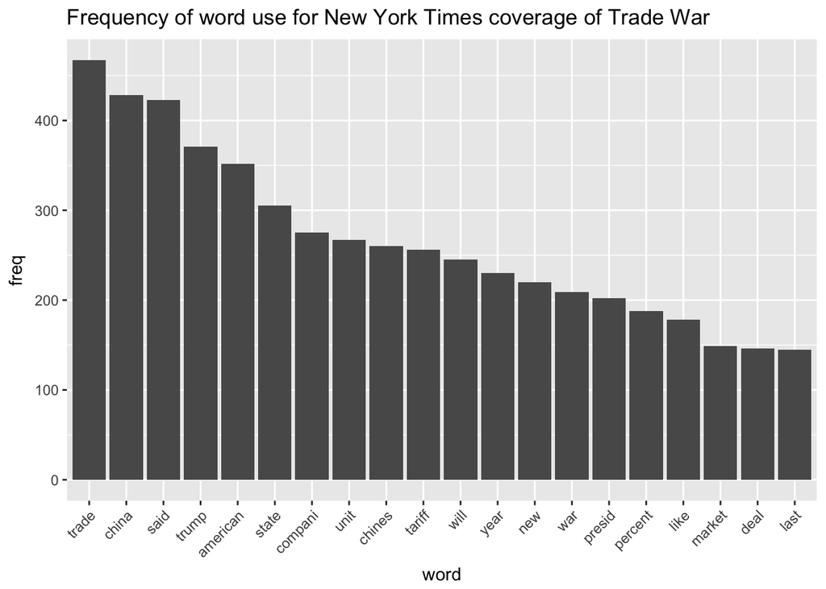

```r
#plot the frequency
nytdocsTidy %>%
  group_by(term) %>%
  summarize(freq = sum(count)) %>%
  top_n(20, freq) %>%
  arrange(desc(freq)) %>%
  ggplot(aes(reorder(term, -freq), freq)) +
  geom_bar(stat="identity") +
  theme(axis.text.x = element_text(angle=45, hjust=1)) + xlab("word") +
  ggtitle("Frequency of word use for New York Times coverage of Trade War")
```

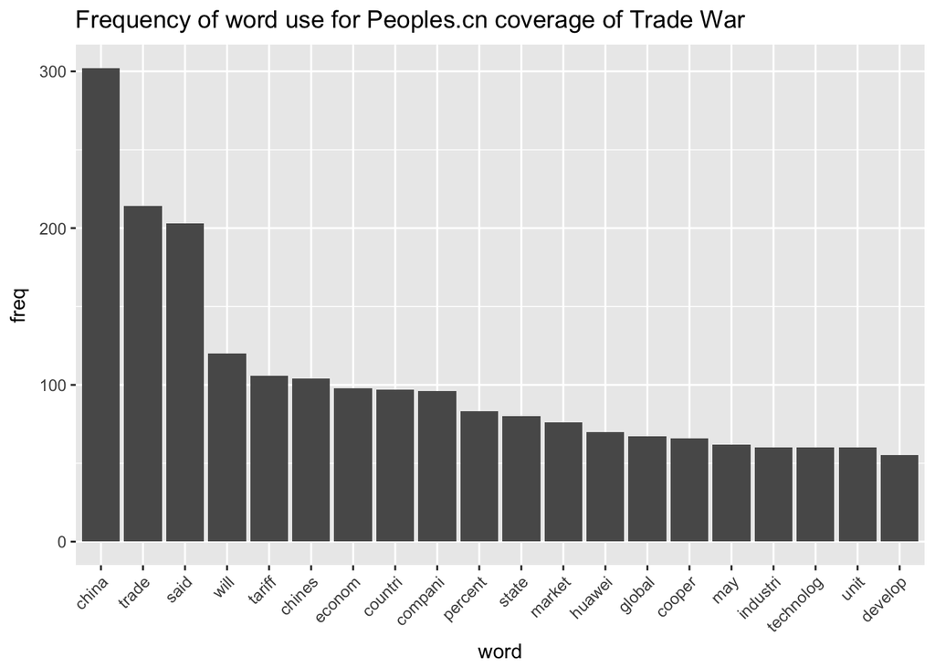

```r
ppldocsTidy %>%
  group_by(term) %>%
  summarize(freq = sum(count)) %>%
  top_n(20, freq) %>%
  arrange(desc(freq)) %>%
  ggplot(aes(reorder(term, -freq), freq)) +
  geom_bar(stat="identity") +
  theme(axis.text.x = element_text(angle=45, hjust=1)) + xlab("word") +
  ggtitle("Frequency of word use for Peoples.cn coverage of Trade War")
```

**We can see that the New York Times focuses more on the political impact of the trade war and Trump’s impact on the trade war whereas the Chinese news source focuses more on China’s economy. The Chinese news source also focuses on Huawei and the technology side of the trade war, which is relatively not that important for the New York Times.**

## Relationships between words: n-grams

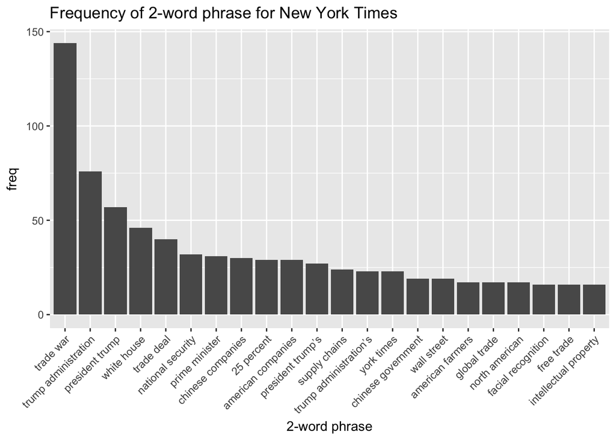

```r
## for New York Times articles
articles <- articles %>%
  select(-content)

nyt_bigrams <- articles %>%
  unnest_tokens(bigram, body, token = "ngrams", n = 2)

#delete stop words
nytbigrams_separated <- nyt_bigrams %>%
  separate(bigram, c("word1", "word2"), sep = " ")

nytbigrams_filtered <- nytbigrams_separated %>%
  filter(!word1 %in% stop_words$word) %>%
  filter(!word2 %in% stop_words$word)



nytbigrams_united <- nytbigrams_filtered %>%
  unite(bigram, word1, word2, sep = " ")

# new bigram counts:
nytbigram_counts <- nytbigrams_united %>%
  count(bigram, sort = TRUE) %>%
  mutate(freq = n)

nytbigram_counts %>%
  top_n(20, freq) %>%
  arrange(desc(freq)) %>%
  ggplot(aes(reorder(bigram, -freq), freq)) +
  geom_bar(stat="identity") +
  theme(axis.text.x = element_text(angle=45, hjust=1)) + xlab("2-word phrase") +
  ggtitle("Frequency of 2-word phrase for New York Times")
```

```r
## for people.cn articles

ppl_bigrams <- df_people %>%
  unnest_tokens(bigram, body, token = "ngrams", n = 2)

#delete stop words
pplbigrams_separated <- ppl_bigrams %>%
  separate(bigram, c("word1", "word2"), sep = " ")

pplbigrams_filtered <- pplbigrams_separated %>%
  filter(!word1 %in% stop_words$word) %>%
  filter(!word2 %in% stop_words$word)



pplbigrams_united <- pplbigrams_filtered %>%
  unite(bigram, word1, word2, sep = " ")

# new bigram counts:
pplbigram_counts <- pplbigrams_united %>%
  count(bigram, sort = TRUE) %>%
  mutate(freq = n)
pplbigram_counts
```

```
## # A tibble: 3,461 x 3
##    bigram                                   n  freq
##    <chr>                                <int> <int>
##  1 addthis_config data_track_addressbar    48    48
##  2 data_track_addressbar false             48    48
##  3 var addthis_config                      48    48
##  4 white paper                             36    36
##  5 additional tariffs                      31    31
##  6 trade war                               19    19
##  7 u.s china                               17    17
##  8 25 percent                              16    16
##  9 arab countries                          16    16
## 10 global supply                           15    15
## # … with 3,451 more rows
```

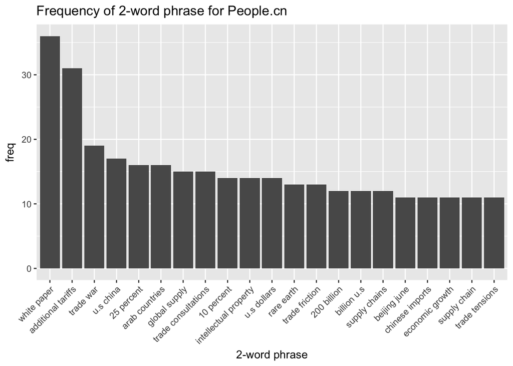

```r
#Notice that the top three bigrams are codelines.
#Therefore, we want to remove these top three
pplbigram_counts %>%
  filter(! bigram %in% c('addthis_config data_track_addressbar', 'data_track_addressbar false', 'var addthis_config')) %>%
  top_n(20, freq) %>%
  arrange(desc(freq)) %>%
  ggplot(aes(reorder(bigram, -freq), freq)) +
  geom_bar(stat="identity") +
  theme(axis.text.x = element_text(angle=45, hjust=1)) + xlab("2-word phrase") +
  ggtitle("Frequency of 2-word phrase for People.cn")
```

**Similar to the previous discovery, we can observe that the news in New York Times focus more on the political side of Trade War.**

# Sentiment Analysis

```r
#generate date for nyt articles
for (i in 1:nrow(articles)){
  articles$time[i] = toString(articles$published_at[i])
}

articles <- articles %>%
  mutate(datetime = mdy_hm(time),
         date = format(datetime, format="%m-%d-%y")
         )
#generate date for people.cn articles

df_people <- df_people %>%
  mutate(datetime = as.Date(df_people$published_at),
         date = format(datetime, format="%m-%d-%y")
         )
# Calculate the sentiments for NYT articles by date
nyt_body <- articles %>%
  select(body, date) %>%
  filter((! is.na(body))) %>%
  filter(body != "") %>%
  mutate(text = toString(body))

tidy_nyt <- nyt_body %>%
  mutate(article_id = row_number()) %>%
  unnest_tokens(word, text)

nyt_sentiment <- tidy_nyt %>%
  inner_join(get_sentiments("bing")) %>%
  count(date, sentiment) %>%
  spread(sentiment, n, fill = 0) %>%
  mutate(sentiment = positive - negative)
nyt_sentiment
```

```
## # A tibble: 17 x 4
##    date     negative positive sentiment
##    <chr>       <dbl>    <dbl>     <dbl>
##  1 05-15-19    17101    16352      -749
##  2 05-16-19    14658    14016      -642
##  3 05-17-19    14658    14016      -642
##  4 05-18-19     7329     7008      -321
##  5 05-19-19     4886     4672      -214
##  6 05-20-19    12215    11680      -535
##  7 05-21-19     7329     7008      -321
##  8 05-22-19     9772     9344      -428
##  9 05-23-19    14658    14016      -642
## 10 05-24-19     7329     7008      -321
## 11 05-25-19     2443     2336      -107
## 12 05-26-19     2443     2336      -107
## 13 05-28-19     9772     9344      -428
## 14 05-29-19     7329     7008      -321
## 15 05-30-19     7329     7008      -321
## 16 05-31-19    26873    25696     -1177
## 17 06-01-19     4886     4672      -214
```

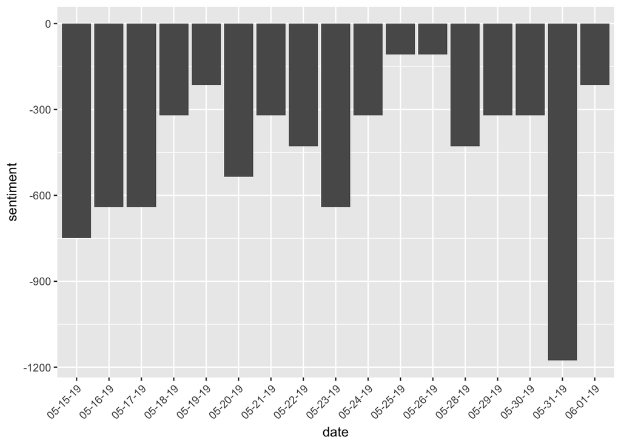

```r
ggplot(nyt_sentiment, aes(date, sentiment)) +
  geom_col(show.legend = FALSE) +
  theme(axis.text.x = element_text(angle=45, hjust=1))
```

```r
# Calculate the sentiments for People.cn articles by date
ppl_body <- df_people %>%
  select(body, date) %>%
  filter((! is.na(body))) %>%
  filter(body != "") %>%
  mutate(text = toString(body))

tidy_ppl <- ppl_body %>%
  mutate(article_id = row_number()) %>%
  unnest_tokens(word, text)

ppl_sentiment <- tidy_ppl %>%
  inner_join(get_sentiments("bing")) %>%
  count(date, sentiment) %>%
  spread(sentiment, n, fill = 0) %>%
  mutate(sentiment = positive - negative)
ppl_sentiment
```

```
## # A tibble: 16 x 4
##    date     negative positive sentiment
##    <chr>       <dbl>    <dbl>     <dbl>
##  1 05-15-19      516      611        95
##  2 05-16-19     1032     1222       190
##  3 05-17-19     1032     1222       190
##  4 05-20-19     1032     1222       190
##  5 05-21-19      516      611        95
##  6 05-22-19     2580     3055       475
##  7 05-23-19      516      611        95
##  8 05-24-19     1032     1222       190
##  9 05-26-19     2064     2444       380
## 10 05-27-19     1548     1833       285
## 11 05-28-19     2064     2444       380
## 12 05-29-19     1548     1833       285
## 13 05-30-19     1032     1222       190
## 14 05-31-19     2064     2444       380
## 15 06-01-19      516      611        95
## 16 06-02-19     5676     6721      1045
```

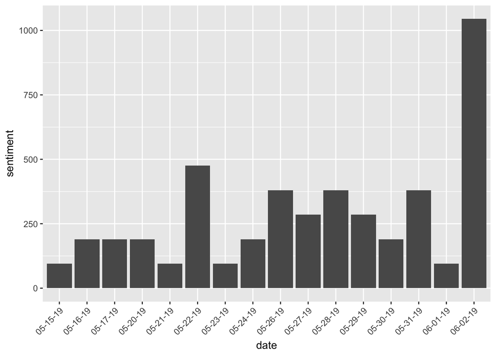

```r
ggplot(ppl_sentiment, aes(date, sentiment)) +
  geom_col(show.legend = FALSE) +
  theme(axis.text.x = element_text(angle=45, hjust=1))
```

** The reason that I decided to use the count of the sentiment rather than use the average method is that the number of articles and the length of the articles are significant. We are more likely to see an increase in the number of articles or the length of the articles when important changes happen and I want to capture this effect. Through the sentiment analysis, we can find out that interestingly, the news coverage in People.cn is more positive in its descriptive tone while that in the New York Times is more negative. One possible reason could be that the Chinese government wants to assure the public that the Trade War situation is not that bad through news propaganda.**